# Writing your own tailor-made user-built functions in R

Larissa Conradt

30 April 2024

## Overview

#### 1. Why write an R function?

#### 2. R user defined **function syntax**

#### 3. Simplistic function without arguments

#### 4. Function input : **The arguments**

#### ……….4.1. Simple function with **one argument**

#### ……….4.2. Function with **several arguments**

#### ……….4.3. Order of **arguments**

#### ……….4.4. **Default values**

#### ……….4.5. Additional (flexible) **arguments**

#### ……….4.6. Fool-prooving your function with respect to **argument inputs**

#### ……….4.7. **Local** and **global** arguments in R

#### 5. Function outputs: **return**

#### 6. Check which **user defined functions** are available within your working environment

#### 7. Create your own **functions library**

#### 8. Suggested websites on R functions

### Preview for potential future C & C

#### 9. Recursive Functions (in preparation)

#### 10. Anonymous (inline / lambda) functions (in preparation)

#### 11. Infix (operator) functions (in preparation)

#### 12. Miscellaneous

#### ……….12.1. What happens if you use the name of a common R function?

#### ……….12.2. Functions as arguments of a function (in preparation)

#### ……….12.3. Vector argument inputs (in preparation)

#### 13. **Function outputs**: change a **global object value**

## 1. Why write an R function?

What is an R function?  
R has got a lot of in-built functions which help enormously with coding.  
A basic but important example is the function **sum()**

```r
num_vect <- c(2, 3, 4, 5, 6, 7, 8, 1, 5, 4, 3, 2, 1, 0, -1, -2, -3, -4, -5, -6)

# Add all the numbers together

# my_sum <- num_vect[1] + num_vect[2] + num_vect[3]  + num_vect[4]  + num_vect[5] + ....
```

The in-built R function **sum()**:

```r
# R in-built function
sum(num_vect)
```

```
## [1] 30
```

- If you have a subroutine which you wish to use repeatedly in different places within your code, or which you wish to use in different code files, it can be very practical to write an R function that contains the subroutine.
- **You can then easily call-up the function every time you require the subroutine.**
- By including argument options in your function, you can also easily re-run the same subroutine for different argument combinations.
- **An R function can save you a lot of coding and make your code more concise, clearer and better structured.**
- You can easily share functions with other co-workers or across the organisation.
- **Using QA-ed and well-tested functions can also help to reduce errors in your code.**

**Consider writing a function whenever you’ve copied and pasted a block of code more than twice**

## 2. R function syntax

**function_name** <– function( **arguments** )  
{  
**function body code**  
}

1. Choose a **function_name** that is different from the names of common functions already existing in R  
   Otherwise your new function overwrites the existing function of the same name. Ideally, the **function_name** should be concise, clear and meaningful to give an idea what the functions does.
2. Assign your R object **function_name** as a **function()**
3. You can choose **arguments** for your function. For each argument, you add a argument name in your syntax:  
   **function (arg1, arg2, arg3, …)**.  
   However, your function does not necessarily have to have arguments. In which case you leave the space within the brackets empty: **function()**.
4. In the **function body**, you write the code for what your function is supposed to do
5. It might be a good idea to add a brief **description** as a “# comment” to your function, so that you know what it is doing.

## 3. Simplistic function without arguments

Let’s start with a very simple function called **simple_fun** that has no arguments and just provides the string “tiger”.

```r
simple_fun <- function()
{

# Description: this function provides the string "tiger"

    "tiger"
}
```

The **simple_fun** is now stored in an R object of class ‘function’. If you want to look at it again, you can just call the object **simple_fun**.

```r
simple_fun
```

```
## function()
## {
##
## # Description: this function provides the string "tiger"
##
##     "tiger"
## }
```

```r
class(simple_fun)
```

```
## [1] "function"
```

If you want to apply the function **simple_fun**, you have to add the brackets (including the function arguments where appropriate): **simple_fun()** and you will get the function output.

```r
simple_fun()
```

```
## [1] "tiger"
```

```r
class(simple_fun())
```

```
## [1] "character"
```

You can easily assign the function output to a new R object.

```r
b <- simple_fun()

b
```

```
## [1] "tiger"
```

## 4. Function input : The arguments

### 4.1. Simple function with **one argument**

The following function **arg1_fun** has got **one argument** and provides different animal strings dependent on the value passed to **argument ‘int1’**.

```r
arg1_fun <- function(int1)
{

# Description: depending on argument int1, this function provides the string:
  # 1 = "tiger", 2 = "kangeroo" or 3 = "dolphin"

  c("tiger", "kangeroo", "dolphin")[int1]

}
```

```r
arg1_fun
```

```
## function(int1)
## {
##
## # Description: depending on argument int1, this function provides the string:
##   # 1 = "tiger", 2 = "kangeroo" or 3 = "dolphin"
##
##   c("tiger", "kangeroo", "dolphin")[int1]
##
## }
```

```r
arg1_fun(1)
```

```
## [1] "tiger"
```

```r
arg1_fun(2)
```

```
## [1] "kangeroo"
```

```r
arg1_fun(3)
```

```
## [1] "dolphin"
```

```r
b <- arg1_fun(2)


b
```

```
## [1] "kangeroo"
```

What happens if the argument input **int1** is out of range?

```r
arg1_fun(6)
```

```
## [1] NA
```

## 4.2. Function with several arguments

The following function has got **four arguments** and draws different types of spirals.

```r
spiral_fun <- function(size, shape, log_boolean, log_shape)
{

# Description: this function draws a spiral
# Archimedean spiral: log_boolean = FALSE, shape = 1
# Logarythmic spiral: log_boolean = TRUE (e.g., log_shape = 0.1)
# Hyperbolic spiral: shape = -1
# Fermat spiral: shape = 0.5
# Lituus spiral: shape = -0.5

  phy = c(2 *pi * c(1:360) / 45)
  r = (1-log_boolean) * size * phy ^ shape + log_boolean * size * exp(phy * log_shape)
  x = r * cos(phy)
  y = r * sin(phy)
  plot(x, y, type = 'l')

}
```

Let’s see what **spiral_fun** does.

```r
# spiral_fun()

# Error in spiral_fun() :
#   argument "size" is missing, with no default
```

The function **spiral_fun** requires **four arguments**. Then can you use the function to easily draw different types of spirals.

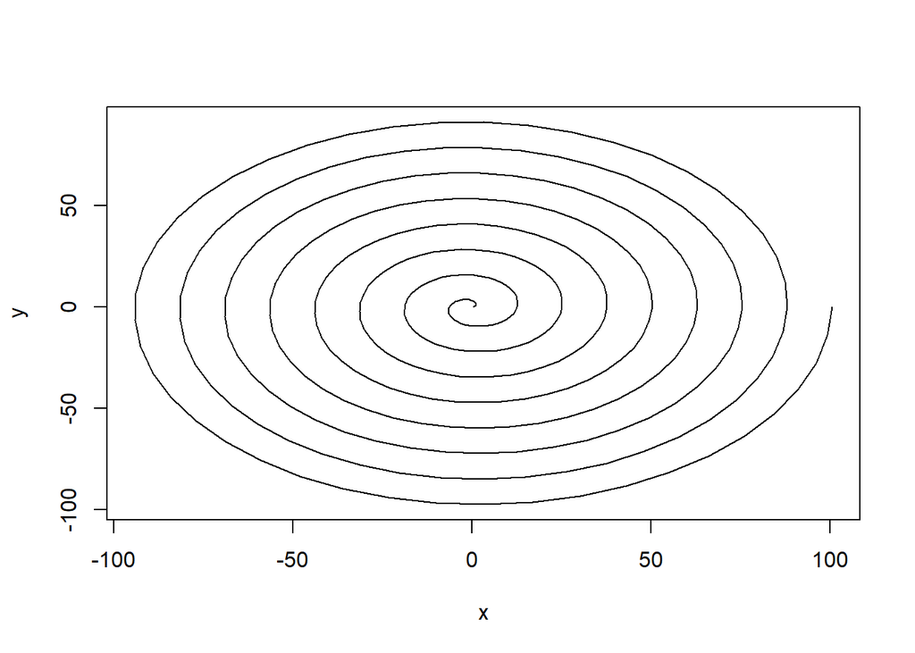

```r
spiral_fun(2, 1, FALSE, 0.1)        # Archimedean
```

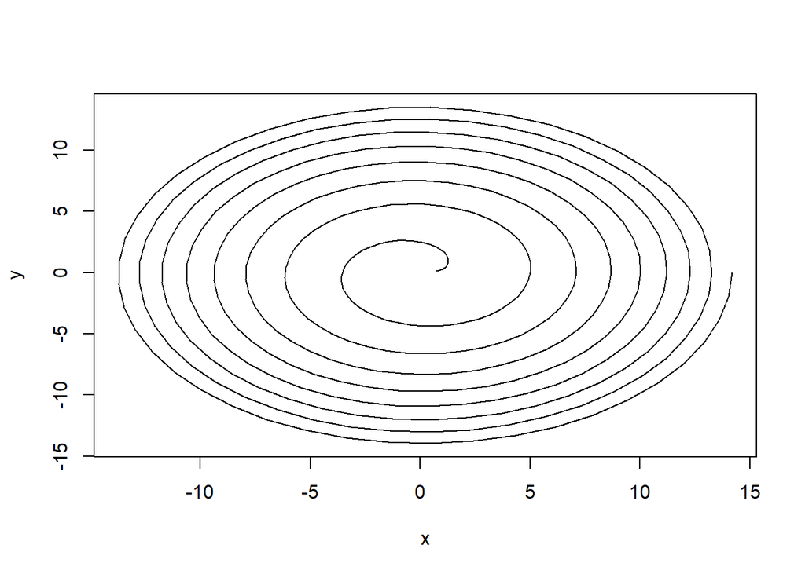

```r
spiral_fun(2, 0.5, FALSE, 0.1)      # Fermat
```

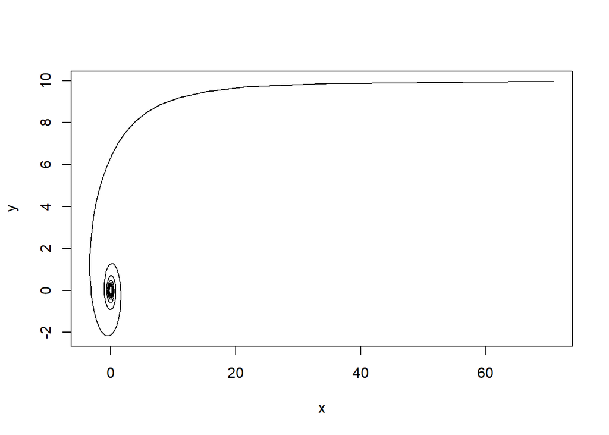

```r
spiral_fun(10, -1, FALSE, 0.1)      # Hyperbolic
```

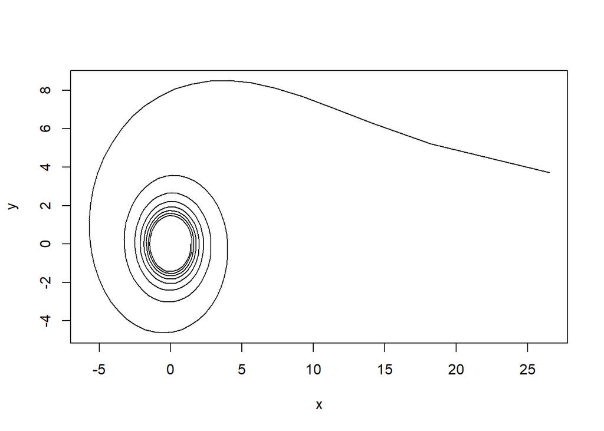

```r
spiral_fun(10, -0.5, FALSE, 0.1)    # Lituus
```

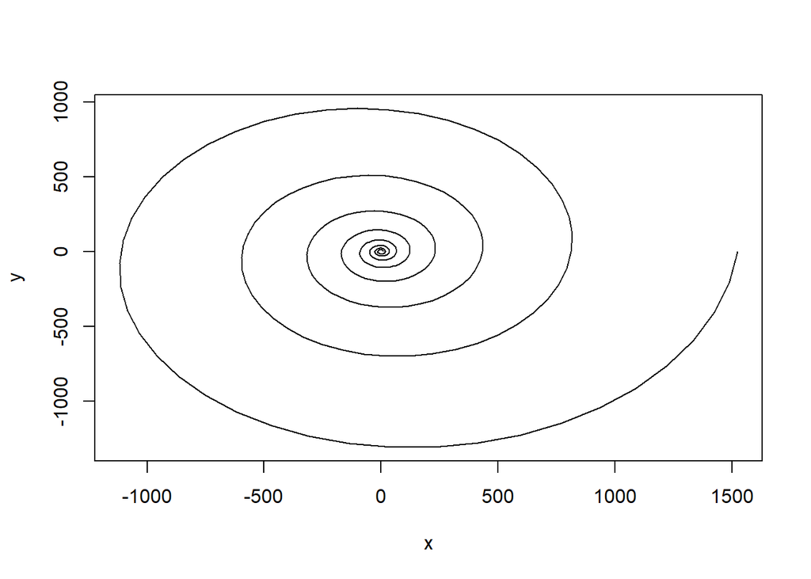

```r
spiral_fun(10, -0.5, TRUE, 0.1)     # Logarithmic
```

Note that **argument values** should be of the required class as defined in your function **spiral_fun**:

**size** is numeric, **shape** is numeric, **log_boolean** is logic, **log_shape** is numeric.

```r
# spiral_fun("t", -0.5, TRUE, 0.1)
# Error in (1 - log_boolean) * size :
#   non-numeric argument to binary operator
```

## 4.3. Order of arguments

If you give **argument input values** to a function without their **argument names**, then you have to make sure the values for the **arguments** are given in the same sequence as in your original function definition: **spiral_fun****(size, shape, log_boolean, log_shape)**.

Otherwise R will not know which of the values is meant to be the **size**, which the **shape**, etc..  
However, if you also supply the **argument names**, you can give the values for the **arguments** in any sequence.  
It is, therefore, often a good idea to provide **argument names** when calling functions with several **arguments**.  
It makes coding simpler, more reliable and also easier to understand if somebody else reads your code.

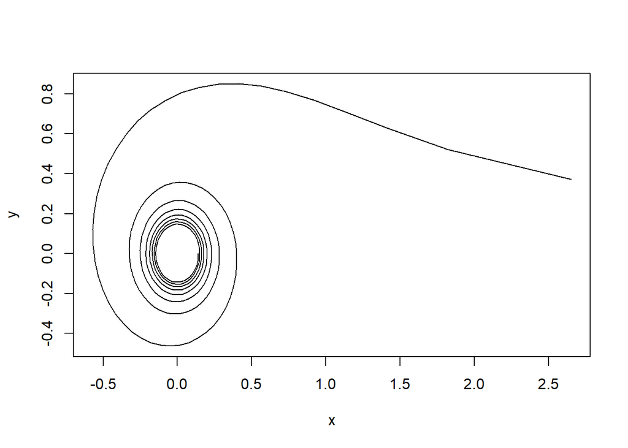

```r
spiral_fun(shape = -0.5, log_boolean = FALSE, log_shape = 0.1, size = 1)
```

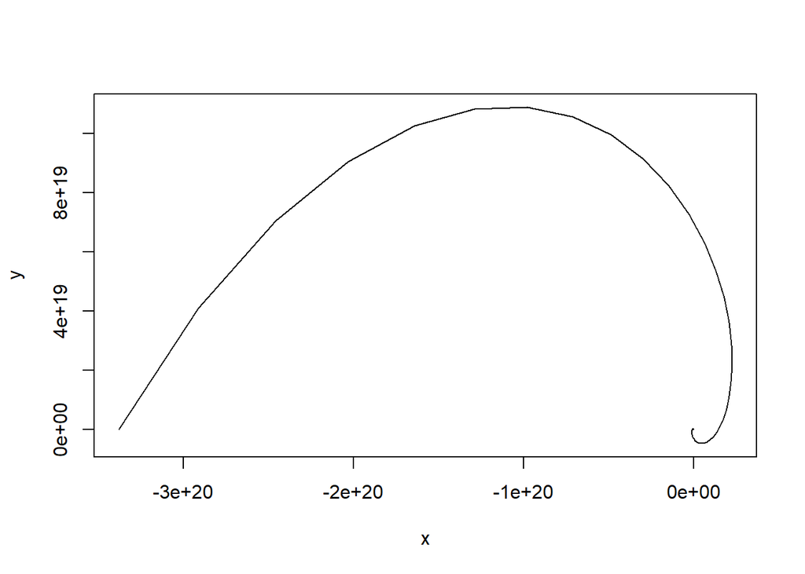

```r
spiral_fun(-0.5, FALSE, 0.1, 1)
```

You can also pass **argument values** to an R object **“arguments_list”** of class “list”, and then use **arguments_list** as argument input in your function. However, you have to do this by using the inbuilt R function **do.call()** with the following syntax:

**do.call ( function_name, arguments_list )**

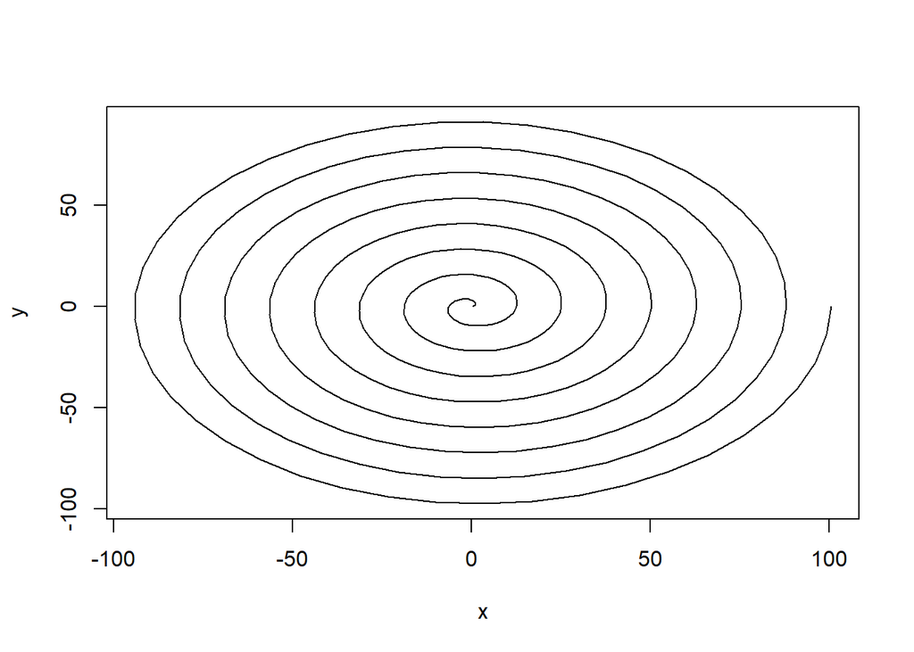

```r
Archimedan <- list(size = 2, shape = 1, log_boolean = FALSE, log_shape = 0.1)

do.call(spiral_fun, Archimedan)
```

## 4.4. Default values

You might wish to have **default values** for some or all of your **arguments**.

You can do that by stating those **default values** when you first define the function.

In the following, the function **spiral_fun** is given the **default values** **“FALSE”** and **“0.1”** for its arguments **log_boolean** and **log_shape**, respectively.

```r
spiral_fun <- function(size, shape, log_boolean = FALSE, log_shape = 0.1)
{

# Description: this function draws a spiral
# Archimedean spiral: log_boolean = FALSE, shape = 1
# Logarythmic spiral: log_boolean = TRUE (e.g., log_shape = 0.1)
# Hyperbolic spiral: shape = -1
# Fermat spiral: shape = 0.5
# Lituus spiral: shape = -0.5

  phy = c(2 *pi * c(1:360) / 45)
  r = (1-log_boolean) * size * phy ^ shape + log_boolean * size * exp(phy * log_shape)
  x = r * cos(phy)
  y = r * sin(phy)
  plot(x, y, type = 'l')

}
```

You now no longer have to supply values for the arguments **log_boolean** and **log_shape** as the function has now **default values** available for those arguments.

However, you can any time overwrite those **default values** when you call you function.

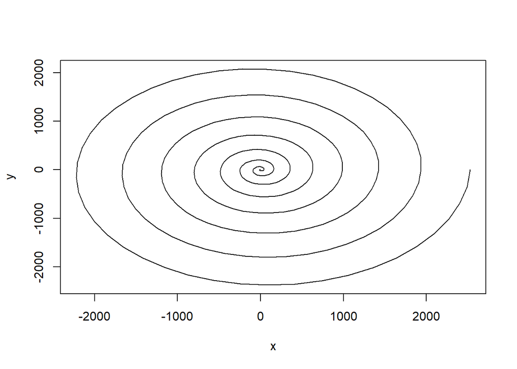

```r
spiral_fun(size = 1, shape = 2)
```

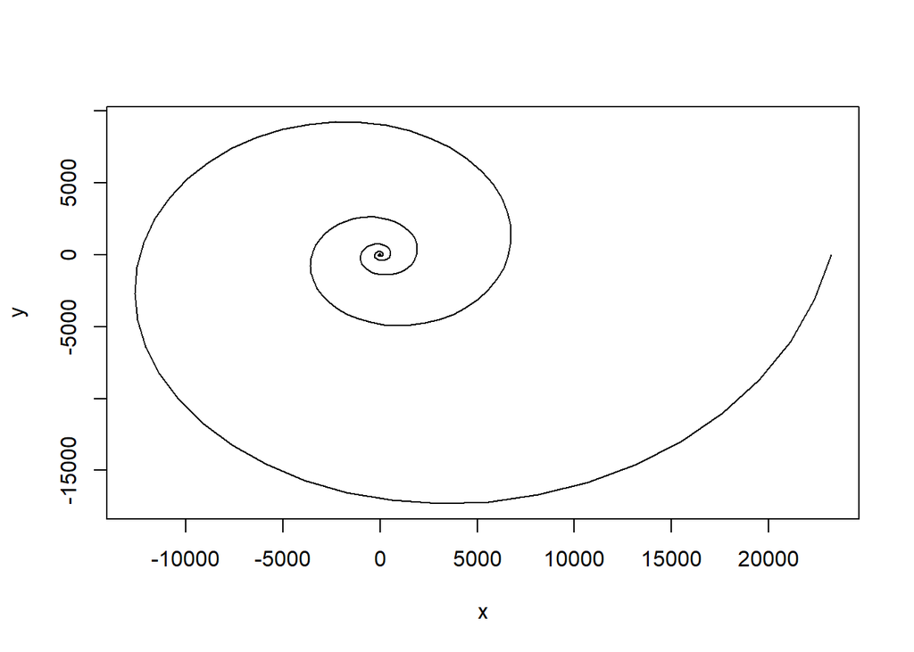

```r
spiral_fun(size = 1, shape = 2, log_boolean = TRUE, log_shape = 0.2)
```

```r
# spiral_fun(log_boolean = TRUE, log_shape = 0.2)
# Error in spiral_fun(log_boolean = TRUE, log_shape = 0.2) :
#   argument "size" is missing, with no default
```

## 4.5. Additional (flexible) arguments

You might want to leave the possibility open to hand additional arguments and argument values to your function.

You can leave this possibility open by adding **…** in your arguments list when defining your function, as follows.

If you do this, you must not forget to also indicate with **…** in your **function body code** where those additional arguments will have to be inserted.

```r
spiral_fun_extra <- function(size = 1, shape = 0.5, log_boolean = FALSE, log_shape = 0.2, ...)
{

# Description: this function draws a spiral
# Archimedean spiral: log_boolean = FALSE, shape = 1
# Logarythmic spiral: log_boolean = TRUE (e.g., log_shape = 0.1)
# Hyperbolic spiral: shape = -1
# Fermat spiral: shape = 0.5
# Lituus spiral: shape = -0.5

  phy = c(2 *pi * c(1:360) / 45)
  r = (1-log_boolean) * size * phy ^ shape + log_boolean * size * exp(phy * log_shape)
  x = r * cos(phy)
  y = r * sin(phy)
  plot(x, y, ...)

}
```

You can now add additional argument values to the function, but you do not have to.

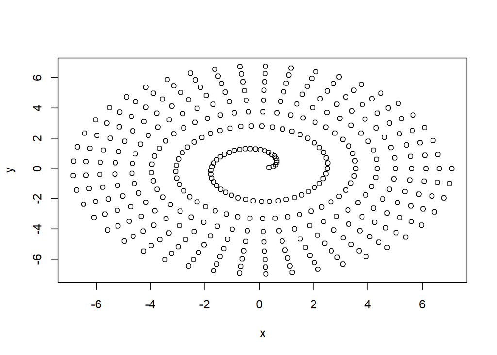

```r
spiral_fun_extra()   # no additional argument values passed
```

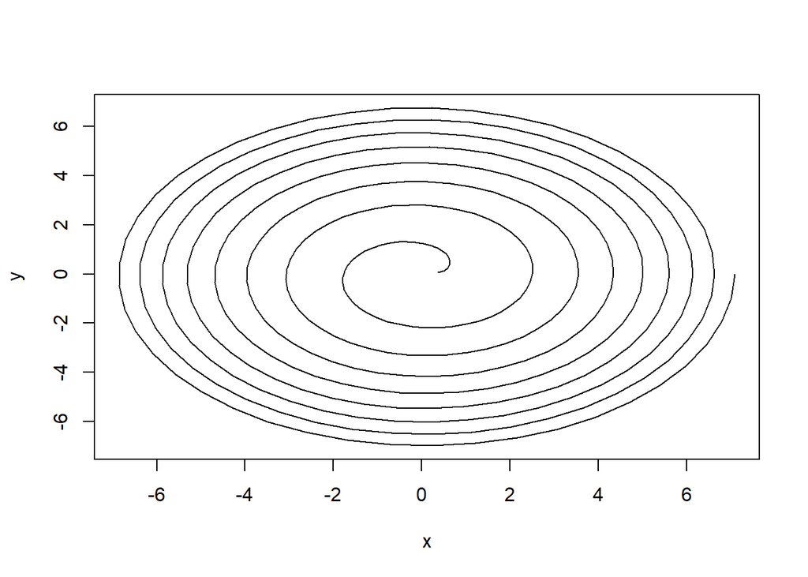

```r
spiral_fun_extra(type='l')  # one additional argument values passed
```